# Introduction to scRNABatchQC

### Visulization of QC metrics

#### plot the distribution of technical factors

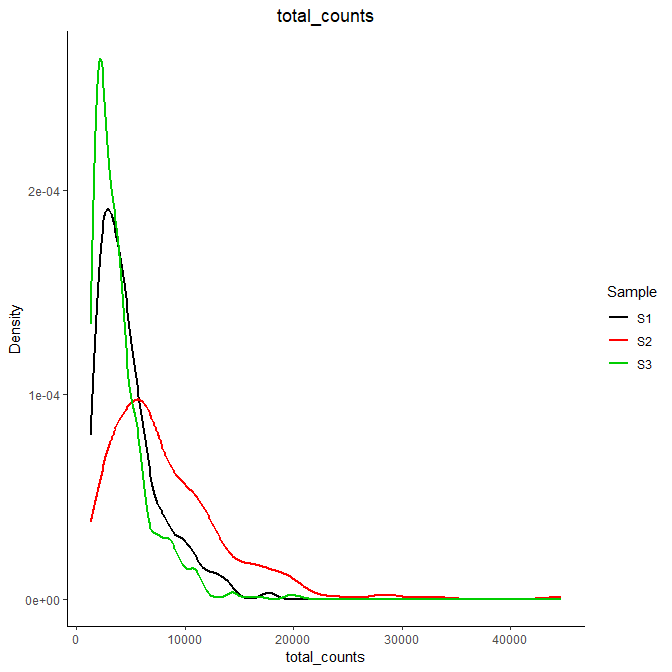

```r
# plot the distribution of the total number of counts
plotDensity(output$sces,"total_counts")
```

[figure not shown]

```r
# plot the distribution of mtRNA fraction
plotDensity(output$sces,"pct_counts_Mt")
```

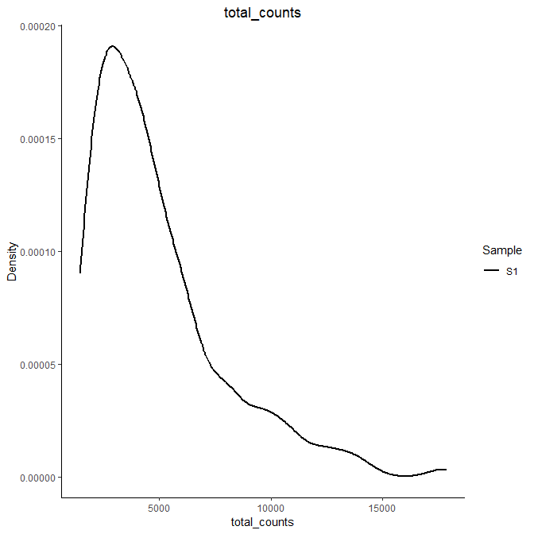

```r
# plot the distribution of the total counts for the first sample
plotDensity(output$sces[1],"total_counts")
```

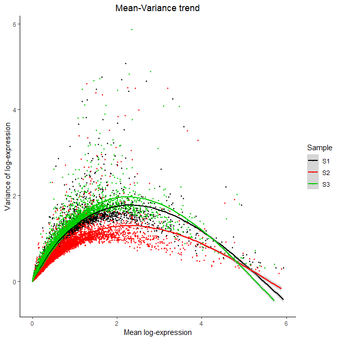

```r
#plot the variance-expression trend
plotVarianceTrend(output$sces)
```

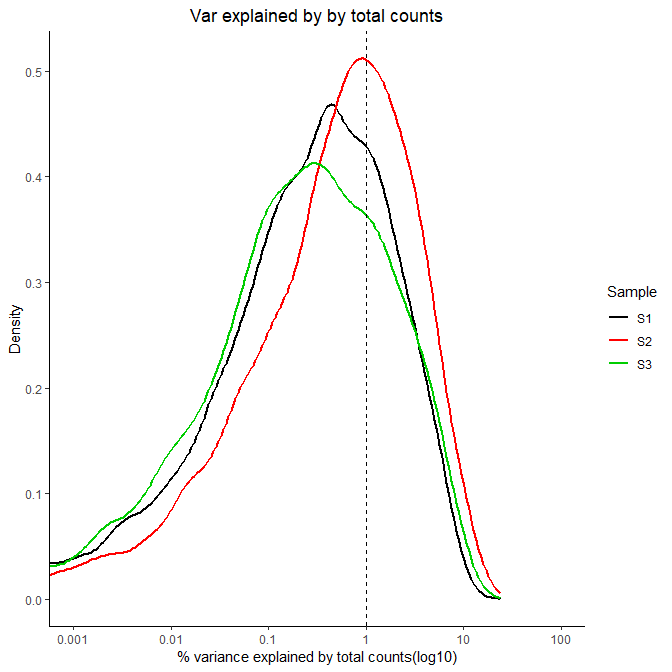

```r
#plot the variance explained by the total counts
plotVarianceExplained(output$sces,feature="genevar_by_counts")
```

#### plot the heatmap of HVGs and PC-related genes

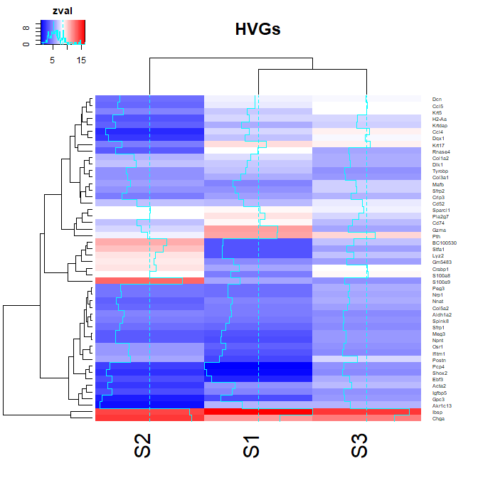

```r
# plot the HVGs
plotHVGs(output$sces)
```

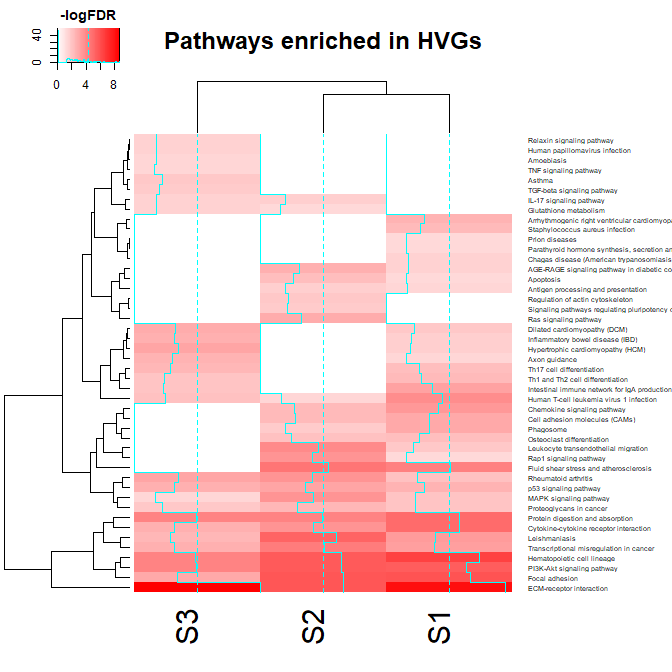

```r
# plot the pathways enriched in the HVGs
plotHVGsPathways(output$sces)
```

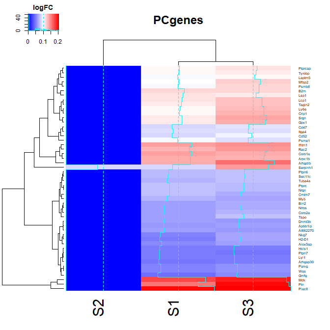

```r
# plot the PC-related genes
plotPCgenes(output$sces)
```

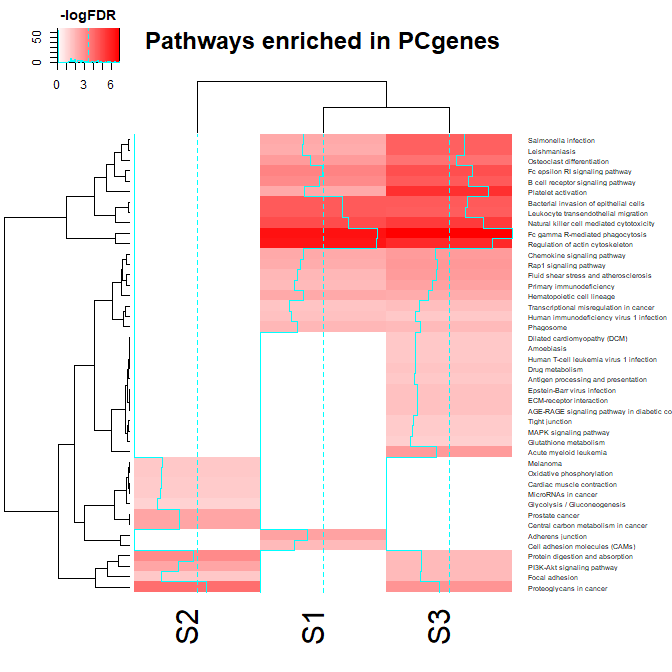

```r
# plot the pathways enriched in pc-related genes
plotPCPathways(output$sces)
```

#### plot the similarity across all samples

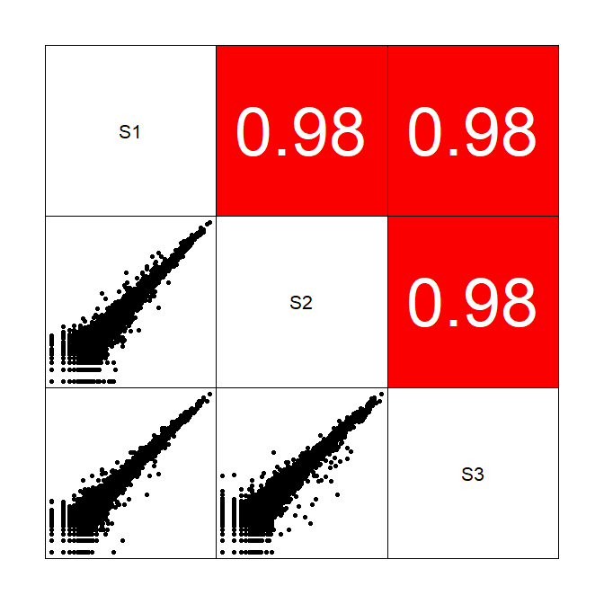

```r
# plot the pairwise similarity of average expression
plotSampleSimilarity(output$sces)
```

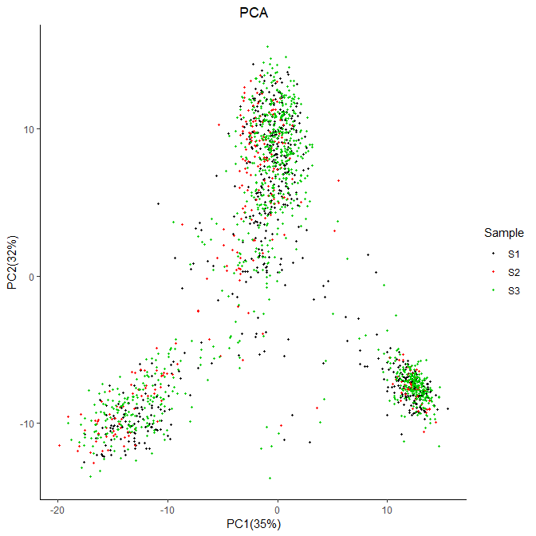

```r
# PCA plots of all samples
plotAllPCA(output$scesMerge)
```

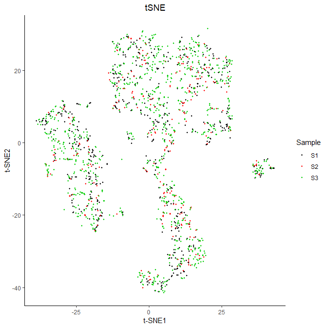

```r
# tSNE plots of all samples
plotAlltSNE(output$scesMerge)
```

#### plot the pairwise differential analysis across samples

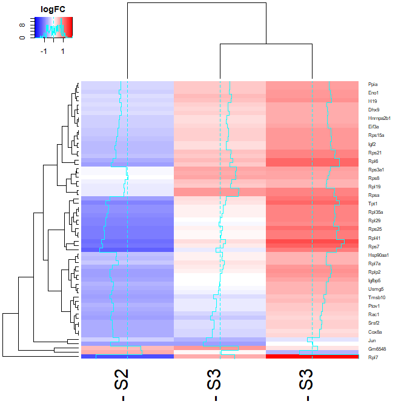

```r
# plot the differentially expressed genes in any pairwise comparison
plotDiffgenes(output$scesMerge)
```

```r
# plot the pathways enriched in DEGs
plotDiffPathways(output$scesMerge)
```

[output not shown]

# Recommendations if out of memory

scRNABatchQC has been tested on multiple platforms (windows, MacOS, linux & CentOS 7) with memory from 4G to 1000G on multiple datasets. Each dataset has 2-6 samples, and each sample has over 20000 genes and 2000-14000 cells. However, the system will probably be out of memory if one sample is very big (huge amount of cells) or there are too many samples (requring a large memory for the merged dataset).

## One sample has huge amount of cells

scRNABatchQC will read the data from each sample at one time and store the data in a sparse matrix. if one sample has huge amount of cells and the system cannot allocate the memory for the sparse matrix, scRNABatchQC provides an parameter (chunk, default:NULL) to read the data by chunk, which will cost time but save memory. The smaller the chunk size, the longer time to read the data but less memory required.

```r
# change the chunk size to save memory
result<-scRNABatchQC(inputfiles=c("https://github.com/liuqivandy/scRNABatchQC/raw/master/bioplar1.csv.gz",
                              "https://github.com/liuqivandy/scRNABatchQC/raw/master/bioplar5.csv.gz"), chunk=2000)
gc()
```

## Too many samples

scRNABatchQC will combine the data from all samples into one sparse matrix. If there are too many samples in the experiment, the sparse matrix could be too big for the memory. In this case, scRNABatchQC provides an parameter (sampleRatio,default: 1) to downsample each sample to generate the combined dataset. sampleRatio=0.1 means that only 10% of original data is combined into the merged dataset. The PCA, tSNE and pairwise comparison will be performed on the downsampled datasets.

```r
# change the sampleRatio to save memory
result<-scRNABatchQC(inputfiles=c("https://github.com/liuqivandy/scRNABatchQC/raw/master/bioplar1.csv.gz",
                              "https://github.com/liuqivandy/scRNABatchQC/raw/master/bioplar5.csv.gz"), sampleRatio = 0.1)
gc()
```